# act_report

## Report: act_report

- Create a **250-word-minimum written report** called "act_report.pdf" or "act_report.html" that communicates the insights and displays the visualization(s) produced from your wrangled data. This is to be framed as an external document, like a blog post or magazine article, for example.

For our given data, from what we were given, and after wrangling it, we have decided that we will discover and look for an answer for the following three question: How much the users rating distripution vary? what charactaristics popo, floofer, etc, are more present in dogs? Does Retweet count affect Favorite count?

And from our analysis, we found a simple direct answer for each of them as the following: For the first question and after creating a scatter plot for the rating data that we have, we found that the users ratings are varying a lot, and there are many outlayers for the ratings, although the dominator is 10, but the ratings varied from 0 up to 250 with some out layers. at the same time, and for the second question, we have compared the four columns of puper, floofer, etc, sumed them and compared them together, and that led us to a significant conclosion which is that the puper dogs are significantly more present in the cute dogs world and in the page data of dogs' photos. Last but not least, the last question we discovered showed us (after plotting both of the columns in a scatter plot) that The retweet_count is dramatically increasing with the increase of favorite_count, whcih is a Positive relationship.

And as a proof for that, we are happy to provide one of our visualizations here in the act report, which is related to our third questoin (Does Retweet count affect Favorite count?), as the folloiwng:

```python
import pandas as pd
import matplotlib.pyplot as plt
Last_frame = pd.read_csv("twitter_archive_master.csv")
```

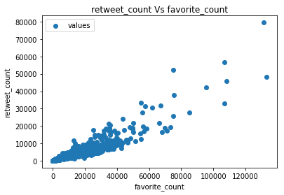

```python
plt.scatter(Last_frame['favorite_count'], Last_frame['retweet_count'], label = "values" )

plt.ylabel('retweet_count')
plt.xlabel('favorite_count')

plt.title('retweet_count Vs favorite_count')
plt.legend()
plt.show()
```